# Mobile App Rating Prediction

Denis O’Byrne

9/18/2021

# Background: This was originally assigned to me as an interview question in a timed test where I was asked to predict the popularity of a mobile app as a binary response (good or bad). I have since found the soure data set and wanted to improve my solution. I do not have my original code so I will have to start from scratch on that end but my thinking will still be along the same lines.

## Data set: [Source found here](https://www.kaggle.com/lava18/google-play-store-apps)

## The data set is the kaggle google play store apps data set linked above provided by lava18

## To validate my model, I will split the dataset as a 70-30 split as there is no hidden data for this challenge.

## To start we will look at the dataset and split the data.

```r
options(width=5000)

mobile_data<-read.csv("C:/Users/denis/Desktop/MobileApp Rating/googleplaystore.csv", header = TRUE)

head(mobile_data)
```

```
##                                                    App       Category Rating Reviews Size    Installs Type Price Content.Rating                    Genres     Last.Updated        Current.Ver  Android.Ver
## 1       Photo Editor & Candy Camera & Grid & ScrapBook ART_AND_DESIGN    4.1     159  19M     10,000+ Free     0       Everyone              Art & Design  January 7, 2018              1.0.0 4.0.3 and up
## 2                                  Coloring book moana ART_AND_DESIGN    3.9     967  14M    500,000+ Free     0       Everyone Art & Design;Pretend Play January 15, 2018              2.0.0 4.0.3 and up
## 3 U Launcher Lite â\200“ FREE Live Cool Themes, Hide Apps ART_AND_DESIGN    4.7   87510 8.7M  5,000,000+ Free     0       Everyone              Art & Design   August 1, 2018              1.2.4 4.0.3 and up
## 4                                Sketch - Draw & Paint ART_AND_DESIGN    4.5  215644  25M 50,000,000+ Free     0           Teen              Art & Design     June 8, 2018 Varies with device   4.2 and up
## 5                Pixel Draw - Number Art Coloring Book ART_AND_DESIGN    4.3     967 2.8M    100,000+ Free     0       Everyone   Art & Design;Creativity    June 20, 2018                1.1   4.4 and up
## 6                           Paper flowers instructions ART_AND_DESIGN    4.4     167 5.6M     50,000+ Free     0       Everyone              Art & Design   March 26, 2017                1.0   2.3 and up
```

## If it is not obvious by now this data is very chaotic and needs to be properly wrangled before we can think about doing any sort of modeling. Lets first split the data so that in the event this were real data our wrangling would need to be reperformed at the end on our new test data. For this reason I will write the data wrangling methods as a function then apply it to both the test and the training set.

## Also note there are some apps where the rating is missing and listed as NaN. Since I would like to be able to test my answer at the end, I am going to remove these points from my dataset. I will make a prediction on these apps at the end however

```r
mob_data<-subset(mobile_data,is.nan(mobile_data$Rating)==FALSE)
```

##I will be using methods from libraries ‘caret’, ‘caTools’, and ‘tidyverse’ for the data splitting so installl these packages if you intend to run the code by uncommenting the following 3 lines

```r
#install.packages('caret')
#install.packages('tidyverse')
#install.packages('caTools')
```

```r
library(tidyverse)
library(caret)
library(caTools)

set.seed(123)
sample <- sample.split(mob_data$Rating, SplitRatio = .70)
training <- subset(mob_data, sample == TRUE)
testing  <- subset(mob_data, sample == FALSE)

dim(training)
```

```
## [1] 6558   13
```

```r
dim(testing)
```

```
## [1] 2809   13
```

## So our training set will contain 6558 samples with 13 rows of variables (12 factors and the response variable Rating) and the testing set will contain 2809 samples.

## Now lets look at some statistics on the training set

```r
summary(training)
```

```
##      App              Category             Rating         Reviews              Size             Installs             Type              Price           Content.Rating        Genres          Last.Updated       Current.Ver        Android.Ver
##  Length:6558        Length:6558        Min.   : 1.000   Length:6558        Length:6558        Length:6558        Length:6558        Length:6558        Length:6558        Length:6558        Length:6558        Length:6558        Length:6558
##  Class :character   Class :character   1st Qu.: 4.000   Class :character   Class :character   Class :character   Class :character   Class :character   Class :character   Class :character   Class :character   Class :character   Class :character
##  Mode  :character   Mode  :character   Median : 4.300   Mode  :character   Mode  :character   Mode  :character   Mode  :character   Mode  :character   Mode  :character   Mode  :character   Mode  :character   Mode  :character   Mode  :character
##                                        Mean   : 4.194
##                                        3rd Qu.: 4.500
##                                        Max.   :19.000
```

# The data storage here actually saves me a step that made me go mad in the interview, as the platform for the exam stored every variable as a factor to start (I dont know why they were not character strings) and converting them from factor to character took a little while to figure out so I will go through 1 variable as if that were the case then treat the rest as they are here

# First I will look at the “Size” variable

```r
head(training$Size, 20)
```

```
##  [1] "19M"  "14M"  "25M"  "5.6M" "19M"  "28M"  "12M"  "20M"  "21M"  "37M"  "17M"  "39M"  "31M"  "12M"  "4.2M" "23M"  "6.0M" "25M"  "4.6M" "9.2M"
```

## To use this variable I will need to remove the unit and multiply by the apporopriate power of 10 then convert to numeric

## As stated before I will include a bit to shw how to deal with this data if it were stored as a factor instead of a character string so I will start by converting to factor

```r
training$Size<-as.factor(training$Size)
levels(training$Size)
```

```
##   [1] "1,000+"             "1.0M"               "1.1M"               "1.2M"               "1.3M"               "1.4M"               "1.5M"               "1.6M"               "1.7M"               "1.8M"               "1.9M"               "10.0M"              "100M"               "103k"            …
## [238] "68M"                "691k"               "696k"               "69M"                "7.0M"               "7.1M"               "7.2M"               "7.3M"               "7.4M"               "7.5M"               "7.6M"               "7.7M"               "7.8M"               "7.9M"            …
```

## From intuition we can guess the units we will be looking for, but if one wanted to they could read through all of the factor levels and find that we will have kilobytes (k), megabytes (M), and gigabytes(G). We can also see from the factor list that some data was stored incorrectly with a size of ‘1000+’ I will decide how to deal with these missing values in a moment but for now we will ignore them.There is also a size listed as “varies with device” which we can account for by setting the variables in this case to a negative value to indicate variable size as all other sizes are positive.

## During the exam it took me a while to come up with a solution to this, but I eventually decided to build an array to store the unit power before I removed the unit then multiply the number left behind after converting the list to numeric. I cannot think of a faster solution, this solution currently takes time O(3N) = O(N) since three passes of the list are made. I think there is a way to do it in two passes but it would require spliting the data in each row as a substring which would be slower I believe.

# Anyways here is a method to restructure the data starting from factor form (we just call lapply as.character on each row first the call as.character on the entire column)

```r
#install.packages(stringr)
```

```r
library(stringr)

training$Size[6375]
```

```
## [1] 1,000+
## Levels: 1,000+ 1.0M 1.1M 1.2M 1.3M 1.4M 1.5M 1.6M 1.7M 1.8M 1.9M 10.0M 100M 103k 10M 118k 11k 11M 121k 122k 12M 13M 141k 143k 144k 14k 14M 153k 154k 15M 160k 161k 164k 169k 16M 173k 175k 17k 17M 186k 18k 18M 190k 192k 196k 19M 2.0M 2.1M 2.2M 2.3M 2.4M 2.5M 2.6M 2.7M 2.8M 2.9M 201k 203k 206k 208k …
```

```r
training$Size<-lapply(training$Size, as.character)
training$Size<-as.character(training$Size)
powers<-c()

for(i in seq(dim(training)[1])){
  if(substr(training$Size[i],str_length(training$Size[i]),str_length(training$Size[i])) == "k"){
    powers<-append(powers,1)
    training$Size[i]<-gsub(".$","",training$Size[i])
  }else if(substr(training$Size[i],str_length(training$Size[i]),str_length(training$Size[i])) == "M"){
    powers<-append(powers,1000)
    training$Size[i]<-gsub(".$","",training$Size[i])
  }else if(substr(training$Size[i],str_length(training$Size[i]),str_length(training$Size[i])) == "G"){
    powers<-append(powers,1000000)
    training$Size[i]<-gsub(".$","",training$Size[i])
  }else if (training$Size[i] == "Varies with device"){
    training$Size[i]<- (-1)
    powers<-append(powers,1)
  }else{
    powers<-append(powers,1)
    training$Size[i]<-gsub(".$","",training$Size[i])
  }
  training$Size[i]<-gsub(",","",training$Size[i])
}

training$Size<-as.numeric(training$Size)

for(i in seq(dim(training)[1])){
  training$Size[i]<-training$Size[i]*powers[i]
}
head(training$Size)
```

```
## [1] 19000 14000 25000  5600 19000 28000
```

```r
which(is.na(training$Size))
```

```
## integer(0)
```

## Now the size variable is properly stored as a continuous variable with a signifier for the case of variable size. Also considering only 1 veriable was stored as 1000+, I will leave it as 1000, this should not affect results

## Next up I will be cleaning the installs variable as it is very similarly bothersome with the trailing + symbol on the values and unnecesary commas. We can use gsub to remove these as seen above.

```r
training[6375,]
```

```
##                                           App Category Rating Reviews Size Installs Type    Price Content.Rating            Genres Last.Updated Current.Ver Android.Ver
## 10473 Life Made WI-Fi Touchscreen Photo Frame      1.9     19    3.0M 1000     Free    0 Everyone                February 11, 2018       1.0.19  4.0 and up
```

```r
training$Installs<-gsub(',', '', training$Installs)
training$Installs<-gsub('\\+', '', training$Installs)
head(training$Installs)
```

```
## [1] "10000"    "500000"   "50000000" "50000"    "50000"    "1000000"
```

```r
training$Installs<-as.numeric(training$Installs)
summary(training$Installs)
```

```
##      Min.   1st Qu.    Median      Mean   3rd Qu.      Max.      NA's
## 1.000e+00 1.000e+04 5.000e+05 1.724e+07 5.000e+06 1.000e+09         1
```

```r
which(is.na(training$Installs))
```

```
## [1] 6375
```

## Something is specifically wrong with training sample 6375 and this was also the case for the Size variable as well as its size was listed as 1000+ which should have been its Installs, if we inspect further we will find that row 6375 is actually missing a category variable and shifted over all the other data to the wrong column by mistake. To correct this I will fix this row later on when I build the function to do all the data cleaning at once.

## Next lets look at the Type and Price column, we can note that these are somewhat repetitive as the Type column just indicates if the Price is zero, so we can remove it if needed

## Looking at the Price column though we need to remove any dollar signs and commas before converting to numeric.

```r
training$Type<-as.factor(training$Type)

training$Price<-gsub(',', '', training$Price)
training$Price<-gsub('\\$', '', training$Price)
training$Price<-as.numeric(training$Price)
summary(training$Price)
```

```
##    Min. 1st Qu.  Median    Mean 3rd Qu.    Max.    NA's
##   0.000   0.000   0.000   1.101   0.000 399.990       1
```

## Only 1 Na which is pesky number 6375 which we saw earlier had a Price of “Everyone”, which should be its Content.Rating

## Now I will convert the Reviews and Ratings variables into numerics

```r
training$Rating<-as.numeric(training$Rating)
training$Reviews<-as.numeric(training$Reviews)
```

## Now we will look at the Content.Rating variable and note that these are category ratings, ao they should be treated as factors

```r
training$Content.Rating<-as.factor(training$Content.Rating)
summary(training$Content.Rating)
```

```
##                 Adults only 18+        Everyone    Everyone 10+      Mature 17+            Teen         Unrated
##               1               3            5228             278             302             745               1
```

## Next up will be the Genres and Category variables. If we look at the data though we find that the Genres variable is actually just the Category variable with some new subcategories if the original category is large enought to warrant a split. We can probably ignore one of these two columns if we want but we should order them as factors which ever one we chose to keep

```r
training$Category<-as.factor(training$Category)

training$Genres<-as.factor(training$Genres)
```

## Now we turn our attention to the Last.Updated Category and find that we have dates of the last update for the app. My solution to dealing with this category is to convert these dates into values counting the number of days that have passed since the date of the last update, so we can store this information as an integer in a new column I will call Days

## First we will need to get these dates into a format that will be usable by a date difference function

## Examining the dates we will see they are listed in (unabriviated month day, year) form which is found using the format “%B %d, %y”

```r
training$Last.Updated<- as.Date(training$Last.Updated, format = "%B %d, %y")
today<-Sys.Date()
training$Days<-0
for(i in seq(dim(training)[1])){
  training$Days[i] <- as.integer(today - training$Last.Updated[i])
}
head(training$Last.Updated)
```

```
## [1] "2020-01-07" "2020-01-15" "2020-06-08" "2020-03-26" "2020-04-26" "2020-10-27"
```

```r
summary(training$Days)
```

```
##    Min. 1st Qu.  Median    Mean 3rd Qu.    Max.    NA's
##   264.0   415.0   435.0   449.4   488.0   629.0       1
```

## Now we turn to the Current.Ver variable which I was unable to figure out a good way to deal with in the alloted time for the Exam. I wanted to extract the numbers for the major release verion (first number before any decimal point) and the major patch to the release (number after first decimal point but before second decimal point)

## Since the exact way versions are stored is so chaotic using the given versions as factors will not be meaningful so something must be done to convert these into a continuous numeric variable.

## I also think it is a good idea to lump weird nonstandard versions into a category as these signify an app made by an independent publisher, as any major software studio will have standardized versioning protocols to adhear to, so I will transform these to a negative value, -1

## There is also a value ‘varies with device’ which I will handle by storing the variable as 0

## I found online a useful solution to this problem on Stack Exchange [linked here](https://stackoverflow.com/questions/67113765/how-to-extract-version-number-from-string-in-r)

```r
for(i in seq(dim(training)[1])){
  s<-training$Current.Ver[i]
  if(s=='Varies with device'){
    s<-'0'
  }
  else{
    s<-regmatches(mobile_data$Current.Ver[i], regexpr("[0-9]+(\\.[0-9]+)?", mobile_data$Current.Ver[i]))
  }

  if(identical(s, character(0))){
    s<-'-1'
  }
  training$Current.Ver[i]<-s
}
training$Current.Ver<-as.numeric(training$Current.Ver)
summary(training$Current.Ver)
```

```
##       Min.    1st Qu.     Median       Mean    3rd Qu.       Max.
##         -1          0          1     216005          3 1255162018
```

## My code is working but there is still an issue with some versions that store the version as the date, I think I will lave this as is for now because my model may be able to spot the similarity of these types anyway.

## Lastly we need to extract the version number from the Android.Ver variable which I can actually do in the exact same way

```r
for(i in seq(dim(training)[1])){
  s<-training$Android.Ver[i]
  if(s=='Varies with device'){
    s<-'0'
  }
  else{
    s<-regmatches(mobile_data$Android.Ver[i], regexpr("[0-9]+(\\.[0-9]+)?", mobile_data$Android.Ver[i]))
  }

  if(identical(s, character(0))){
    s<-'-1'
  }
  training$Android.Ver[i]<-s
}
training$Android.Ver<-as.numeric(training$Android.Ver)
summary(training$Android.Ver)
```

```
##    Min. 1st Qu.  Median    Mean 3rd Qu.    Max.
##  -1.000   0.000   4.000   2.666   4.100   8.000
```

```r
length(which(training$Android.Ver==-1))
```

```
## [1] 971
```

# Now that we are done cleaning the data we can convert all these techniques into a function that will clean any data

## Also we will fix training sample 6375

```r
clean_data<-function(training){
  library(stringr)

  training$Size[6375]

  training$Size<-lapply(training$Size, as.character)
  training$Size<-as.character(training$Size)
  powers<-c()

  for(i in seq(dim(training)[1])){
    if(substr(training$Size[i],str_length(training$Size[i]),str_length(training$Size[i])) == "k"){
      powers<-append(powers,1)
      training$Size[i]<-gsub(".$","",training$Size[i])
    }else if(substr(training$Size[i],str_length(training$Size[i]),str_length(training$Size[i])) == "M"){
      powers<-append(powers,1000)
      training$Size[i]<-gsub(".$","",training$Size[i])
    }else if(substr(training$Size[i],str_length(training$Size[i]),str_length(training$Size[i])) == "G"){
      powers<-append(powers,1000000)
      training$Size[i]<-gsub(".$","",training$Size[i])
    }else if (training$Size[i] == "Varies with device"){
      training$Size[i]<- (-1)
      powers<-append(powers,1)
    }else{
      powers<-append(powers,1)
      training$Size[i]<-gsub(".$","",training$Size[i])
    }
    training$Size[i]<-gsub(",","",training$Size[i])
  }

  training$Size<-as.numeric(training$Size)

  for(i in seq(dim(training)[1])){
    training$Size[i]<-training$Size[i]*powers[i]
  }


  training$Installs<-gsub(',', '', training$Installs)
  training$Installs<-gsub('\\+', '', training$Installs)
  training$Installs<-as.numeric(training$Installs)

  training$Type<-as.factor(training$Type)

  training$Price<-gsub(',', '', training$Price)
  training$Price<-gsub('\\$', '', training$Price)
  training$Price<-as.numeric(training$Price)

  training$Rating<-as.numeric(training$Rating)

  training$Reviews<-as.numeric(training$Reviews)

  training$Content.Rating<-as.factor(training$Content.Rating)

  training$Category<-as.factor(training$Category)

  training$Genres<-as.factor(training$Genres)

  training$Last.Updated<- as.Date(training$Last.Updated, format = "%B %d, %y")
  today<-Sys.Date()
  training$Days<-0
  for(i in seq(dim(training)[1])){
    training$Days[i] <- as.integer(today - training$Last.Updated[i])
  }

  for(i in seq(dim(training)[1])){
    s<-training$Current.Ver[i]
    if(s=='Varies with device'){
      s<-'0'
    }
    else{
      s<-regmatches(mobile_data$Current.Ver[i], regexpr("[0-9]+(\\.[0-9]+)?", mobile_data$Current.Ver[i]))
    }

    if(identical(s, character(0))){
      s<-'-1'
    }
    training$Current.Ver[i]<-s
  }
  training$Current.Ver<-as.numeric(training$Current.Ver)

  for(i in seq(dim(training)[1])){
    s<-training$Android.Ver[i]
    if(s=='Varies with device'){
      s<-'0'
    }
    else{
      s<-regmatches(mobile_data$Android.Ver[i], regexpr("[0-9]+(\\.[0-9]+)?", mobile_data$Android.Ver[i]))
    }

    if(identical(s, character(0))){
      s<-'-1'
    }
    training$Android.Ver[i]<-s
  }
  training$Android.Ver<-as.numeric(training$Android.Ver)

  return(training)
}
```

## Note by using argument name training I didnt need to change anything about my previous work

## Now lets reset the data and fix the the funky sample 6375

## From the name of the app we can tell the app category and genre should be “PHOTOGRAPHY” and “Photography” so we will impute that as well as shift over all the data to the correct columns

```r
set.seed(123)
sample <- sample.split(mob_data$Rating, SplitRatio = .70)
training <- subset(mob_data, sample == TRUE)
testing  <- subset(mob_data, sample == FALSE)

dim(training)
```

```
## [1] 6558   13
```

```r
dim(testing)
```

```
## [1] 2809   13
```

```r
mess<-training[6375,]
fixed<-mess

for(i in seq(length(mess),2)){
  fixed[i]<-mess[i-1]
}
fixed$Category<-"PHOTOGRAPHY"
fixed$Genres<-"Photography"
training[6375,]<-fixed


training<-clean_data(training = training)
summary(training)
```

```
##      App                    Category        Rating         Reviews              Size           Installs           Type          Price               Content.Rating           Genres      Last.Updated         Current.Ver          Android.Ver          Days
##  Length:6558        FAMILY      :1240   Min.   :1.000   Min.   :       1   Min.   :    -1   Min.   :1.000e+00   Free:6112   Min.   :  0.0   Adults only 18+:   3   Tools        : 516   Min.   :2020-01-01   Min.   :        -1   Min.   :-1.000   Min.   :264.0
##  Class :character   GAME        : 765   1st Qu.:4.000   1st Qu.:     187   1st Qu.:  2400   1st Qu.:1.000e+04   Paid: 446   1st Qu.:  0.0   Everyone       :5229   Entertainment: 368   1st Qu.:2020-05-21   1st Qu.:         0   1st Qu.: 0.000   1st Qu.:415.0
##  Mode  :character   TOOLS       : 516   Median :4.300   Median :    5886   Median :  9500   Median :5.000e+05               Median :  0.0   Everyone 10+   : 278   Education    : 324   Median :2020-07-13   Median :         1   Median : 4.000   Median :435.0
##                     PRODUCTIVITY: 245   Mean   :4.191   Mean   :  487186   Mean   : 19109   Mean   :1.724e+07               Mean   :  1.1   Mature 17+     : 302   Action       : 248   Mean   :2020-06-28   Mean   :    216005   Mean   : 2.666   Mean   :449.4
##                     MEDICAL     : 242   3rd Qu.:4.500   3rd Qu.:   81377   3rd Qu.: 27000   3rd Qu.:5.000e+06               3rd Qu.:  0.0   Teen           : 745   Productivity : 245   3rd Qu.:2020-08-02   3rd Qu.:         3   3rd Qu.: 4.100   3rd Qu.:488.0
##                     PHOTOGRAPHY : 240   Max.   :5.000   Max.   :78128208   Max.   :100000   Max.   :1.000e+09               Max.   :400.0   Unrated        :   1   Medical      : 242   Max.   :2020-12-31   Max.   :1255162018   Max.   : 8.000   Max.   :629.0
##                     (Other)     :3310                                                                                                                              (Other)      :4615
```

```r
testing<-clean_data(training = testing)
```

# Now that our data is properly cleaned we can begin analysis and modeling

## First lets decide which variables to include in our model, then I will transform the data frame into a model matrix to include dummy variables for factor levels

## As mentioned previously Category and Genres are highly correlated, with Genres being more specific with smaller group sizes, so for my analysis I will drop the Genres category to avoid over fitting.

## Also previously mentioned the Type variable just signifies if the Price variable is 0 so we can drop Type

## I converted the Last.Update Variable into the Days variable so we can drop Last.Update

## We should not include the App name as a variable since this is just a row identifier

## Ratings will be our Response variable

## Thus our model features will be (“Category”, “Reviews”, “Size”, “Installs”, “Price”, “Content.Rating”,“Current.Ver”, “Android.Ver”, “Days”)

# Now we can build our model matrix of dummy variables

```r
train_data<-training[c("Category", "Rating", "Reviews", "Size", "Installs", "Price", "Content.Rating","Current.Ver", "Android.Ver", "Days")]
dummy_Train<-model.matrix(Rating~.,train_data)
head(dummy_Train)
```

```
##    (Intercept) CategoryAUTO_AND_VEHICLES CategoryBEAUTY CategoryBOOKS_AND_REFERENCE CategoryBUSINESS CategoryCOMICS CategoryCOMMUNICATION CategoryDATING CategoryEDUCATION CategoryENTERTAINMENT CategoryEVENTS CategoryFAMILY CategoryFINANCE CategoryFOOD_AND_DRINK CategoryGAME CategoryHEALTH_AND_FIT…
## 1            1                         0              0                           0                0              0                     0              0                 0                     0              0              0               0                      0            0                       …
## 2            1                         0              0                           0                0              0                     0              0                 0                     0              0              0               0                      0            0                       …
## 4            1                         0              0                           0                0              0                     0              0                 0                     0              0              0               0                      0            0                       …
## 6            1                         0              0                           0                0              0                     0              0                 0                     0              0              0               0                      0            0                       …
## 7            1                         0              0                           0                0              0                     0              0                 0                     0              0              0               0                      0            0                       …
## 11           1                         0              0                           0                0              0                     0              0                 0                     0              0              0               0                      0            0                       …
```

```r
dim(dummy_Train)
```

```
## [1] 6558   45
```

```r
train_y<-train_data$Rating
```

# From here we can now use some dimension reduction methods such as Random Forest gini importance or LASSO Regularized Regression or Principal Component Analysis to determine the variables to include in our model

## First I will perform build a Random Forest Model and remove Features with minimum importance

```r
#install.packages("randomForest")
#install.packages("e1071")
library(randomForest)
library(e1071)

set.seed(742)

rf_Model1<-randomForest(dummy_Train,train_y, ntree=100, max_nodes = 1000, importance = T)

importance(rf_Model1)
```

```
##                                %IncMSE IncNodePurity
## (Intercept)                  0.0000000  0.000000e+00
## CategoryAUTO_AND_VEHICLES   -0.4369979  5.334865e+00
## CategoryBEAUTY               0.3848935  1.595957e+00
## CategoryBOOKS_AND_REFERENCE  3.8126506  6.597714e+00
## CategoryBUSINESS            -1.2619420  1.543818e+01
## CategoryCOMICS              -0.1725084  5.825958e+00
## CategoryCOMMUNICATION        2.1833757  1.060685e+01
## CategoryDATING               4.1555910  1.554546e+01
## CategoryEDUCATION            4.6106285  2.844448e+00
## CategoryENTERTAINMENT        5.6667322  3.478886e+00
## CategoryEVENTS              -2.9034581  1.689562e+00
## CategoryFAMILY               0.1036175  2.090364e+01
## CategoryFINANCE              1.1868300  1.679464e+01
## CategoryFOOD_AND_DRINK       2.6256290  8.722188e+00
## CategoryGAME                 6.5473149  1.044265e+01
## CategoryHEALTH_AND_FITNESS   6.3468387  1.867381e+01
## CategoryHOUSE_AND_HOME       1.0738271  2.284149e+00
## CategoryLIBRARIES_AND_DEMO   3.9598692  3.060903e+00
## CategoryLIFESTYLE            2.3804219  1.591288e+01
## CategoryMAPS_AND_NAVIGATION  2.1181027  6.689640e+00
## CategoryMEDICAL             -1.6702605  1.690691e+01
## CategoryNEWS_AND_MAGAZINES  -2.2021722  1.110818e+01
## CategoryPARENTING            4.7801427  2.677134e+00
## CategoryPERSONALIZATION      5.1980439  7.022376e+00
## CategoryPHOTOGRAPHY          2.9794795  1.429325e+01
## CategoryPRODUCTIVITY        -0.9232225  1.132503e+01
## CategorySHOPPING             2.5608699  5.672567e+00
## CategorySOCIAL               3.2361895  7.229054e+00
## CategorySPORTS               0.4461670  1.295347e+01
## CategoryTOOLS                3.4984296  2.235808e+01
## CategoryTRAVEL_AND_LOCAL     7.1256219  1.074317e+01
## CategoryVIDEO_PLAYERS        6.3122498  9.928884e+00
## CategoryWEATHER             -1.2722364  1.824431e+00
## Reviews                     18.7570434  3.240102e+02
## Size                        10.0387951  1.920102e+02
## Installs                    12.7074626  1.576935e+02
## Price                        9.3266327  3.613507e+01
## Content.RatingEveryone       5.2708520  1.365895e+01
## Content.RatingEveryone 10+   3.6068430  6.850610e+00
## Content.RatingMature 17+     4.4653713  8.961647e+00
## Content.RatingTeen           3.8059207  9.842261e+00
## Content.RatingUnrated        0.0000000  5.469689e-03
## Current.Ver                  2.9217352  1.421678e+02
## Android.Ver                  4.6802259  9.613751e+01
## Days                         6.9733722  2.186569e+02
```

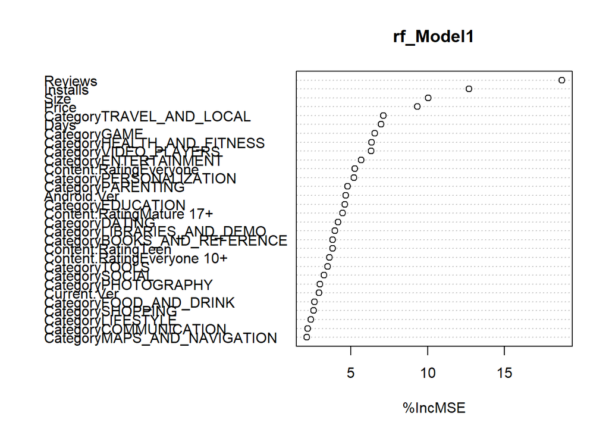

```r
varImpPlot(rf_Model1, type = 1)
```

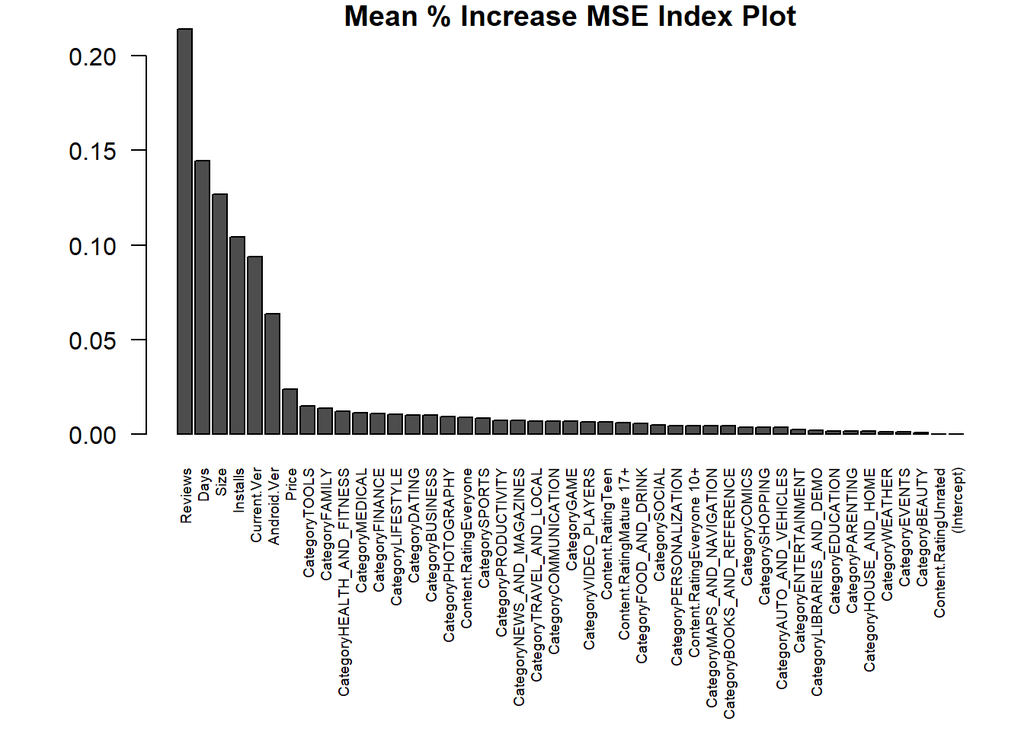

```r
var.imp1 <- data.frame(importance(rf_Model1, type=2))
var.imp1$Variables <- row.names(var.imp1)
varimp1 <- var.imp1[order(var.imp1[1],decreasing = T),]
par(mar=c(10,5,1,1))
giniplot <- barplot(t(varimp1[-2]/sum(varimp1[-2])),las=2,
                     cex.names=0.6,
                    main="Mean % Increase MSE Index Plot")
```